# payment_value_care_EDA

```python
import pandas as pd
import numpy as np
import matplotlib.pyplot as plt
import seaborn as sns
```

```python
pv_care_hos=pd.read_csv(r"/content/sample_data/Payment_and_Value_of_Care-Hospital.csv")
pv_care_hos.head(5)
```

|  | Facility ID | Facility Name | Address | City/Town | State | ZIP Code | County/Parish | Telephone Number | Payment Measure ID | Payment Measure Name | ... | Payment | Lower Estimate | Higher Estimate | Payment Footnote | Value of Care Display ID | Value of Care Display Name | Value of Care Category | Value of Care Footnote | Start Date | End Date |
| --- | --- | --- | --- | --- | --- | --- | --- | --- | --- | --- | --- | --- | --- | --- | --- | --- | --- | --- | --- | --- | --- |
| 0 | 10001 | SOUTHEAST HEALTH MEDICAL CENTER | 1108 ROSS CLARK CIRCLE | DOTHAN | AL | 36301 | HOUSTON | (334) 793-8701 | PAYM_30_AMI | Payment for heart attack patients | ... | $28,502 | $26,229 | $30,939 | NaN | MORT_PAYM_30_AMI | Value of Care Heart Attack measure | Average Mortality and Average Payment | NaN | 07/01/2020 | 06/30/2023 |
| 1 | 10001 | SOUTHEAST HEALTH MEDICAL CENTER | 1108 ROSS CLARK CIRCLE | DOTHAN | AL | 36301 | HOUSTON | (334) 793-8701 | PAYM_30_HF | Payment for heart failure patients | ... | $20,602 | $19,572 | $21,713 | NaN | MORT_PAYM_30_HF | Value of Care Heart Failure measur | Average Mortality and Average Payment | NaN | 07/01/2020 | 06/30/2023 |
| 2 | 10001 | SOUTHEAST HEALTH MEDICAL CENTER | 1108 ROSS CLARK CIRCLE | DOTHAN | AL | 36301 | HOUSTON | (334) 793-8701 | PAYM_30_PN | Payment for pneumonia patients | ... | $22,404 | $21,247 | $23,627 | NaN | MORT_PAYM_30_PN | Value of Care Pneumonia measure | Average Mortality and Higher Payment | NaN | 07/01/2020 | 06/30/2023 |
| 3 | 10001 | SOUTHEAST HEALTH MEDICAL CENTER | 1108 ROSS CLARK CIRCLE | DOTHAN | AL | 36301 | HOUSTON | (334) 793-8701 | PAYM_90_HIP_KNEE | Payment for hip/knee replacement patients | ... | $22,819 | $20,082 | $26,007 | NaN | COMP_PAYM_90_HIP_KNEE | Value of Care hip/knee replacement | Average Complications and Average Payment | NaN | 07/01/2020 | 03/31/2023 |
| 4 | 10005 | MARSHALL MEDICAL CENTERS | 2505 U S HIGHWAY 431 NORTH | BOAZ | AL | 35957 | MARSHALL | (256) 593-8310 | PAYM_30_AMI | Payment for heart attack patients | ... | $26,561 | $22,721 | $30,858 | NaN | MORT_PAYM_30_AMI | Value of Care Heart Attack measure | Average Mortality and Average Payment | NaN | 07/01/2020 | 06/30/2023 |

5 rows × 22 columns

```python
pv_care_hos.columns = pv_care_hos.columns.str.replace(' ', '_')
```

```python
pv_care_hos.columns
```

```
Index(['Facility_ID', 'Facility_Name', 'Address', 'City/Town', 'State',
       'ZIP_Code', 'County/Parish', 'Telephone_Number', 'Payment_Measure_ID',
       'Payment_Measure_Name', 'Payment_Category', 'Denominator', 'Payment',
       'Lower_Estimate', 'Higher_Estimate', 'Payment_Footnote',
       'Value_of_Care_Display_ID', 'Value_of_Care_Display_Name',
       'Value_of_Care_Category', 'Value_of_Care_Footnote', 'Start_Date',
       'End_Date'],
      dtype='object')
```

# Data Exploration

```python
pv_care_hos.info()
```

```
<class 'pandas.core.frame.DataFrame'>
RangeIndex: 18500 entries, 0 to 18499
Data columns (total 22 columns):
 #   Column                      Non-Null Count  Dtype
---  ------                      --------------  -----
 0   Facility_ID                 18500 non-null  int64
 1   Facility_Name               18500 non-null  object
 2   Address                     18500 non-null  object
 3   City/Town                   18500 non-null  object
 4   State                       18500 non-null  object
 5   ZIP_Code                    18500 non-null  int64
 6   County/Parish               18500 non-null  object
 7   Telephone_Number            18500 non-null  object
 8   Payment_Measure_ID          18500 non-null  object
 9   Payment_Measure_Name        18500 non-null  object
 10  Payment_Category            18500 non-null  object
 11  Denominator                 18500 non-null  object
 12  Payment                     18500 non-null  object
 13  Lower_Estimate              18500 non-null  object
 14  Higher_Estimate             18500 non-null  object
 15  Payment_Footnote            8612 non-null   object
 16  Value_of_Care_Display_ID    18500 non-null  object
 17  Value_of_Care_Display_Name  18500 non-null  object
 18  Value_of_Care_Category      18500 non-null  object
 19  Value_of_Care_Footnote      8510 non-null   float64
 20  Start_Date                  18500 non-null  object
 21  End_Date                    18500 non-null  object
dtypes: float64(1), int64(2), object(19)
memory usage: 3.1+ MB
```

```python
pv_care_hos.isna().sum()
```

|  | 0 |
| --- | --- |
| Facility_ID | 0 |
| Facility_Name | 0 |
| Address | 0 |
| City/Town | 0 |
| State | 0 |
| ZIP_Code | 0 |
| County/Parish | 0 |
| Telephone_Number | 0 |
| Payment_Measure_ID | 0 |
| Payment_Measure_Name | 0 |
| Payment_Category | 0 |
| Denominator | 0 |
| Payment | 0 |
| Lower_Estimate | 0 |
| Higher_Estimate | 0 |
| Payment_Footnote | 9888 |
| Value_of_Care_Display_ID | 0 |
| Value_of_Care_Display_Name | 0 |
| Value_of_Care_Category | 0 |
| Value_of_Care_Footnote | 9990 |
| Start_Date | 0 |
| End_Date | 0 |

**dtype:** int64

```python
#checking $ and ',' are removed but still Payment	Lower Estimate	Higher Estimate in object type
pd.DataFrame(pv_care_hos['Payment'].unique()).head(5)
```

|  | 0 |
| --- | --- |
| 0 | $28,502 |
| 1 | $20,602 |
| 2 | $22,404 |
| 3 | $22,819 |
| 4 | $26,561 |

```python
pv_numeric = pv_care_hos[["Payment", "Lower_Estimate", "Higher_Estimate",'Denominator']]
pv_numeric
```

|  | Payment | Lower_Estimate | Higher_Estimate | Denominator |
| --- | --- | --- | --- | --- |
| 0 | $28,502 | $26,229 | $30,939 | 290 |
| 1 | $20,602 | $19,572 | $21,713 | 590 |
| 2 | $22,404 | $21,247 | $23,627 | 468 |
| 3 | $22,819 | $20,082 | $26,007 | 32 |
| 4 | $26,561 | $22,721 | $30,858 | 26 |
| ... | ... | ... | ... | ... |
| 18495 | Not Available | Not Available | Not Available | Not Available |
| 18496 | Not Available | Not Available | Not Available | Not Available |
| 18497 | Not Available | Not Available | Not Available | Not Available |
| 18498 | $19,848 | $16,982 | $22,787 | 42 |
| 18499 | $22,031 | $19,841 | $24,496 | 57 |

18500 rows × 4 columns

# Data cleaning

- coverting Payment,lower_estimate,higher_estimate,denominator to numeric

```python
#Payment	Lower Estimate	Higher Estimate
pv_numeric['Payment'] = pv_numeric['Payment'].str.replace('$', '').str.replace(',', '').str.replace("Not Available",'')
pv_numeric['Lower_Estimate'] = pv_numeric['Lower_Estimate'].str.replace('$', '').str.replace(',', '').str.replace("Not Available",'')
pv_numeric['Higher_Estimate'] = pv_numeric['Higher_Estimate'].str.replace('$', '').str.replace(',', '').str.replace("Not Available",'')
pv_numeric['Denominator'] = pv_numeric['Denominator'].str.replace(',', '').str.replace("Not Available",'')
```

```python
pv_numeric.head(20)
```

|  | Payment | Lower_Estimate | Higher_Estimate | Denominator |
| --- | --- | --- | --- | --- |
| 0 | 28502 | 26229 | 30939 | 290 |
| 1 | 20602 | 19572 | 21713 | 590 |
| 2 | 22404 | 21247 | 23627 | 468 |
| 3 | 22819 | 20082 | 26007 | 32 |
| 4 | 26561 | 22721 | 30858 | 26 |
| 5 | 18056 | 16496 | 19814 | 157 |
| 6 | 20284 | 18892 | 21716 | 283 |
| 7 | 17498 | 16418 | 18682 | 138 |
| 8 | 31366 | 28808 | 34136 | 281 |
| 9 | 19466 | 18363 | 20691 | 438 |
| 10 | 21743 | 20667 | 22859 | 581 |
| 11 | 21796 | 19919 | 23834 | 83 |
| 12 |  |  |  |  |
| 13 | 19572 | 16865 | 22597 | 34 |
| 14 | 19649 | 17373 | 21884 | 94 |
| 15 | 21221 | 18652 | 24180 | 33 |
| 16 |  |  |  |  |
| 17 |  |  |  |  |
| 18 | 20760 | 17071 | 24482 | 26 |
| 19 |  |  |  |  |

```python
pv_numeric.info()
```

```
<class 'pandas.core.frame.DataFrame'>
RangeIndex: 18500 entries, 0 to 18499
Data columns (total 4 columns):
 #   Column           Non-Null Count  Dtype
---  ------           --------------  -----
 0   Payment          18500 non-null  object
 1   Lower_Estimate   18500 non-null  object
 2   Higher_Estimate  18500 non-null  object
 3   Denominator      18500 non-null  object
dtypes: object(4)
memory usage: 578.2+ KB
```

```python
# converting payment,lower estimate,higher estimate to int64

pv_numeric["Payment"] = pd.to_numeric(pv_numeric["Payment"], errors='coerce').astype('Int64')
pv_numeric["Lower_Estimate"] = pd.to_numeric(pv_numeric["Lower_Estimate"], errors='coerce').astype('Int64')
pv_numeric["Higher_Estimate"] = pd.to_numeric(pv_numeric["Higher_Estimate"], errors='coerce').astype('Int64')
pv_numeric["Denominator"] = pd.to_numeric(pv_numeric["Denominator"], errors='coerce').astype('Int64')
```

```python
pv_numeric["Payment"].fillna(round(pv_numeric["Payment"].mean()), inplace=True) # Round the mean to the nearest integer
pv_numeric["Lower_Estimate"].fillna(round(pv_numeric["Lower_Estimate"].mean()), inplace=True) # Round the mean to the nearest integer
pv_numeric["Higher_Estimate"].fillna(round(pv_numeric["Higher_Estimate"].mean()), inplace=True) # Round the mean to the nearest integer
pv_numeric["Denominator"].fillna(round(pv_numeric["Denominator"].mean()), inplace=True) # Round the mean to the nearest integer
```

[output not shown]

```python
pv_numeric.isnull().sum()
```

|  | 0 |
| --- | --- |
| Payment | 0 |
| Lower_Estimate | 0 |
| Higher_Estimate | 0 |
| Denominator | 0 |

**dtype:** int64

```python
pv_numeric['Denominator'].fillna(round(pv_numeric['Denominator'].mean()), inplace=True)
```

```python
pv_numeric.isnull().sum()
```

|  | 0 |
| --- | --- |
| Payment | 0 |
| Lower_Estimate | 0 |
| Higher_Estimate | 0 |
| Denominator | 0 |

**dtype:** int64

```python
pv_care_hos.columns
```

```
Index(['Facility_ID', 'Facility_Name', 'Address', 'City/Town', 'State',
       'ZIP_Code', 'County/Parish', 'Telephone_Number', 'Payment_Measure_ID',
       'Payment_Measure_Name', 'Payment_Category', 'Denominator', 'Payment',
       'Lower_Estimate', 'Higher_Estimate', 'Payment_Footnote',
       'Value_of_Care_Display_ID', 'Value_of_Care_Display_Name',
       'Value_of_Care_Category', 'Value_of_Care_Footnote', 'Start_Date',
       'End_Date'],
      dtype='object')
```

```python
pv_care_hos = pv_care_hos.drop(pv_care_hos[['Denominator',"Payment",'Lower_Estimate','Higher_Estimate']], axis=1)
# pv_care_hos = pv_care_hos.drop(pv_care_hos[['Payment','Lower_Estimate','Higher_Estimate']], axis=1)
```

# Route 2 : checking payment category

```python
pv_care_hos['Payment_Category'].unique()
```

```
array(['No Different Than the National Average Payment',
       'Greater Than the National Average Payment',
       'Less Than the National Average Payment',
       'Number of Cases Too Small', 'Not Available'], dtype=object)
```

```python
payment_category_mode = pv_care_hos['Payment_Category'].mode()[0]
```

```python
print(pv_care_hos['Payment_Category'].value_counts())
```

```
Payment_Category
No Different Than the National Average Payment    7255
Number of Cases Too Small                         5203
Not Available                                     3296
Less Than the National Average Payment            1490
Greater Than the National Average Payment         1256
Name: count, dtype: int64
```

```python
pv_care_hos['Payment_Category'].replace('Not Available',payment_category_mode, inplace=True)
```

```python
pv_care_hos['Payment_Category'].value_counts()
```

| Payment_Category | count |
| --- | --- |
| No Different Than the National Average Payment | 10551 |
| Number of Cases Too Small | 5203 |
| Less Than the National Average Payment | 1490 |
| Greater Than the National Average Payment | 1256 |

**dtype:** int64

```python
# removing facility id empty space and converting to numeric
pv_care_hos['Facility_ID'] = pv_care_hos['Facility_ID'].astype(str).str.replace(' ', '').astype('int64')
```

```python
pv_care_hos['Facility_ID'].head(10)
```

|  | Facility_ID |
| --- | --- |
| 0 | 10001 |
| 1 | 10001 |
| 2 | 10001 |
| 3 | 10001 |
| 4 | 10005 |
| 5 | 10005 |
| 6 | 10005 |
| 7 | 10005 |
| 8 | 10006 |
| 9 | 10006 |

**dtype:** int64

```python
pv_care_hos.columns
```

```
Index(['Facility_ID', 'Facility_Name', 'Address', 'City/Town', 'State',
       'ZIP_Code', 'County/Parish', 'Telephone_Number', 'Payment_Measure_ID',
       'Payment_Measure_Name', 'Payment_Category', 'Payment_Footnote',
       'Value_of_Care_Display_ID', 'Value_of_Care_Display_Name',
       'Value_of_Care_Category', 'Value_of_Care_Footnote', 'Start_Date',
       'End_Date'],
      dtype='object')
```

```python
pv_numeric.columns
```

```
Index(['Payment', 'Lower_Estimate', 'Higher_Estimate', 'Denominator'], dtype='object')
```

```python
pv_numeric.describe()
```

|  | Payment | Lower_Estimate | Higher_Estimate | Denominator |
| --- | --- | --- | --- | --- |
| count | 18500.0 | 18500.0 | 18500.0 | 18500.0 |
| mean | 22238.957946 | 20100.943081 | 24544.899892 | 204.112216 |
| std | 2765.149424 | 2468.904526 | 3236.909222 | 166.350011 |
| min | 14058.0 | 11651.0 | 16099.0 | 25.0 |
| 25% | 20861.0 | 19059.0 | 22836.75 | 114.0 |
| 50% | 22239.0 | 20101.0 | 24545.0 | 204.0 |
| 75% | 22239.0 | 20101.0 | 24545.0 | 204.0 |
| max | 52527.0 | 45861.0 | 60861.0 | 4155.0 |

- all varaibles are right skewed means clustered on lower end with fewer values

```python
# prompt: print median for pv_numeric
for i in pv_numeric.columns:
  print(" median of ",i,pv_numeric[i].median())
# print(pv_numeric['Payment'].median())
```

```
 median of  Payment 22239.0
 median of  Lower_Estimate 20101.0
 median of  Higher_Estimate 24545.0
 median of  Denominator 204.0
```

# route 3: checking for outliers

```python
pv_numeric.columns
```

```
Index(['Payment', 'Lower_Estimate', 'Higher_Estimate', 'Denominator'], dtype='object')
```

```python
from scipy.stats import iqr

columns = pv_numeric.columns
IQR = {}
lower_threshold = {}
upper_threshold = {}

for col in columns:
    IQR[col] = iqr(pv_numeric[col])


    lower_threshold[col] = np.quantile(pv_numeric[col], 0.25) - 1.5 * IQR[col]
    upper_threshold[col] = np.quantile(pv_numeric[col], 0.75) + 1.5 * IQR[col]

print(f'IQR: {IQR}\n')
print(f'Lower thresholds: {lower_threshold}\n')
print(f'Upper thresholds: {upper_threshold}')
```

```
IQR: {'Payment': 1378.0, 'Lower_Estimate': 1042.0, 'Higher_Estimate': 1708.25, 'Denominator': 90.0}

Lower thresholds: {'Payment': 18794.0, 'Lower_Estimate': 17496.0, 'Higher_Estimate': 20274.375, 'Denominator': -21.0}

Upper thresholds: {'Payment': 24306.0, 'Lower_Estimate': 21664.0, 'Higher_Estimate': 27107.375, 'Denominator': 339.0}
```

```python
lower_thresholds = {'Payment': 18794.0, 'Lower_Estimate': 17496.0, 'Higher_Estimate': 20274.375,'Denominator': -21.0}
upper_thresholds = {'Payment': 24306.0, 'Lower_Estimate': 21664.0, 'Higher_Estimate': 27107.375,'Denominator': 339.0}

#Removing outliers based on the thresholds
for column in lower_thresholds:
    df = pv_numeric[(pv_numeric[column] >= lower_thresholds[column]) & (pv_numeric[column] <= upper_thresholds[column])]

#Displaying the DataFrame after removing outliers
df.head()
```

|  | Payment | Lower_Estimate | Higher_Estimate | Denominator |
| --- | --- | --- | --- | --- |
| 0 | 28502 | 26229 | 30939 | 290 |
| 3 | 22819 | 20082 | 26007 | 32 |
| 4 | 26561 | 22721 | 30858 | 26 |
| 5 | 18056 | 16496 | 19814 | 157 |
| 6 | 20284 | 18892 | 21716 | 283 |

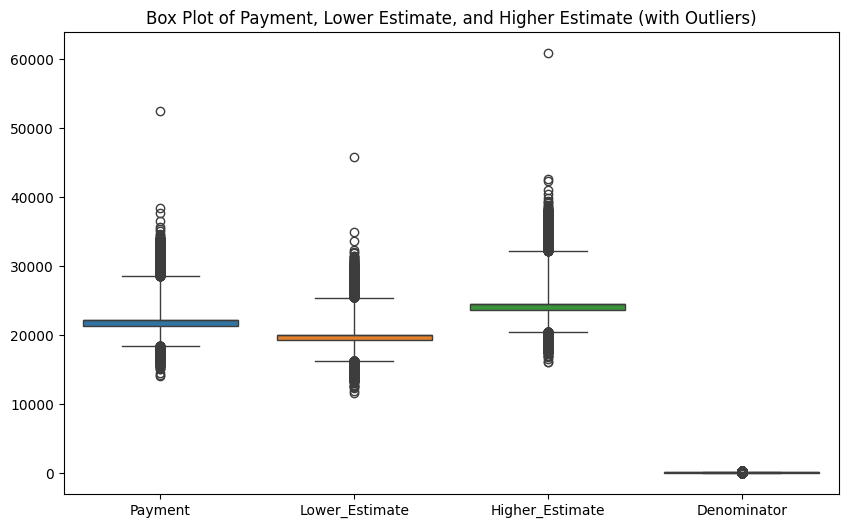

```python
plt.figure(figsize=(10, 6))
sns.boxplot(data=df, whis=[5, 95])  # Adjust whisker range to show outliers beyond the 5th and 95th percentiles
plt.title('Box Plot of Payment, Lower Estimate, and Higher Estimate (with Outliers)')
plt.show()
```

# Conclusion

- No need to remove outilers as they are true information from the source (mentioned in website)

```python
pv_care_hos.info()
```

```
<class 'pandas.core.frame.DataFrame'>
RangeIndex: 18500 entries, 0 to 18499
Data columns (total 18 columns):
 #   Column                      Non-Null Count  Dtype
---  ------                      --------------  -----
 0   Facility_ID                 18500 non-null  int64
 1   Facility_Name               18500 non-null  object
 2   Address                     18500 non-null  object
 3   City/Town                   18500 non-null  object
 4   State                       18500 non-null  object
 5   ZIP_Code                    18500 non-null  int64
 6   County/Parish               18500 non-null  object
 7   Telephone_Number            18500 non-null  object
 8   Payment_Measure_ID          18500 non-null  object
 9   Payment_Measure_Name        18500 non-null  object
 10  Payment_Category            18500 non-null  object
 11  Payment_Footnote            8612 non-null   object
 12  Value_of_Care_Display_ID    18500 non-null  object
 13  Value_of_Care_Display_Name  18500 non-null  object
 14  Value_of_Care_Category      18500 non-null  object
 15  Value_of_Care_Footnote      8510 non-null   float64
 16  Start_Date                  18500 non-null  object
 17  End_Date                    18500 non-null  object
dtypes: float64(1), int64(2), object(15)
memory usage: 2.5+ MB
```

- Payment_Footnote - 8612 records - (50% of data is present and also have null values ) - Ignore this column(suggestion)
- value_of_care_footnote - 8510 records -(50% of data is present and also have null values ) - Ignore this column(suggestion)

# Data cleaning route 5

- Payment_Measure_ID
- Payment_Measure_Name

```python
print( "unique values ",pv_care_hos['Payment_Measure_ID'].unique())
print(pv_care_hos['Payment_Measure_ID'].value_counts())
print(" null values ",pv_care_hos['Payment_Measure_Name'].isnull().sum())
```

```
unique values  ['PAYM_30_AMI' 'PAYM_30_HF' 'PAYM_30_PN' 'PAYM_90_HIP_KNEE']
Payment_Measure_ID
PAYM_30_AMI         4625
PAYM_30_HF          4625
PAYM_30_PN          4625
PAYM_90_HIP_KNEE    4625
Name: count, dtype: int64
 null values  0
```

```python
print( "unique values ",pv_care_hos['Payment_Measure_Name'].unique())
print(pv_care_hos['Payment_Measure_Name'].value_counts())
print(" null values ",pv_care_hos['Payment_Measure_Name'].isnull().sum())
```

```
unique values  ['Payment for heart attack patients' 'Payment for heart failure patients'
 'Payment for pneumonia patients'
 'Payment for hip/knee replacement patients']
Payment_Measure_Name
Payment for heart attack patients            4625
Payment for heart failure patients           4625
Payment for pneumonia patients               4625
Payment for hip/knee replacement patients    4625
Name: count, dtype: int64
 null values  0
```

### observation: both payment-measure-name and payment-measure-ID are same , we can remove one of them for analysis purpose

### *data* cleaning : Step 6

- Value_of_Care_Display_ID
- Value_of_Care_Display_Name
- Value_of_Care_Category
- Value_of_Care_Footnote - 8510 -float64 - not useful for analysis

[output not shown]

```python
print( "unique values ",pv_care_hos['Value_of_Care_Display_ID'].unique())
print(pv_care_hos['Value_of_Care_Display_ID'].value_counts())
print(" null values ",pv_care_hos['Value_of_Care_Display_ID'].isnull().sum())
```

```
unique values  ['MORT_PAYM_30_AMI' 'MORT_PAYM_30_HF' 'MORT_PAYM_30_PN'
 'COMP_PAYM_90_HIP_KNEE']
Value_of_Care_Display_ID
MORT_PAYM_30_AMI         4625
MORT_PAYM_30_HF          4625
MORT_PAYM_30_PN          4625
COMP_PAYM_90_HIP_KNEE    4625
Name: count, dtype: int64
 null values  0
```

```python
print( "unique values ",pv_care_hos['Value_of_Care_Display_Name'].unique())
print(pv_care_hos['Value_of_Care_Display_Name'].value_counts())
print(" null values ",pv_care_hos['Value_of_Care_Display_Name'].isnull().sum())
```

```
unique values  ['Value of Care Heart Attack measure' 'Value of Care Heart Failure measur'
 'Value of Care Pneumonia measure' 'Value of Care hip/knee replacement']
Value_of_Care_Display_Name
Value of Care Heart Attack measure    4625
Value of Care Heart Failure measur    4625
Value of Care Pneumonia measure       4625
Value of Care hip/knee replacement    4625
Name: count, dtype: int64
 null values  0
```

```python
print( "unique values ",pv_care_hos['Value_of_Care_Category'].unique())
print(pv_care_hos['Value_of_Care_Category'].value_counts())
print(" null values ",pv_care_hos['Value_of_Care_Category'].isnull().sum())
```

```
unique values  ['Average Mortality and Average Payment'
 'Average Mortality and Higher Payment'
 'Average Complications and Average Payment'
 'Worse Mortality and Average Payment'
 'Average Complications and Lower Payment'
 'Worse Mortality and Higher Payment' 'Not Available'
 'Average Mortality and Lower Payment' 'Worse Mortality and Lower Payment'
 'Better Mortality and Average Payment'
 'Average Complications and Higher Payment'
 'Better Mortality and Higher Payment'
 'Better Mortality and Lower Payment'
 'Worse Complications and Average Payment'
 'Better Complications and Lower Payment'
 'Worse Complications and Higher Payment'
 'Worse Complications and Lower Payment'
 'Better Complications and Average Payment']
Value_of_Care_Category
Not Available                                8510
Average Mortality and Average Payment        5768
Average Complications and Average Payment     980
Average Mortality and Lower Payment           878
Average Mortality and Higher Payment          861
Average Complications and Lower Payment       438
Better Mortality and Average Payment          279
Worse Mortality and Average Payment           214
Average Complications and Higher Payment      191
Better Mortality and Higher Payment           142
Better Mortality and Lower Payment             90
Worse Mortality and Lower Payment              58
Worse Mortality and Higher Payment             56
Better Complications and Lower Payment         25
Worse Complications and Higher Payment          4
Worse Complications and Average Payment         3
Better Complications and Average Payment        2
Worse Complications and Lower Payment           1
Name: count, dtype: int64
 null values  0
```

- need to discuss about this

```python
pv_care_hos.head()
print(pv_care_hos.shape)
pv_care_hos.columns
```

```
(18500, 18)
```

```
Index(['Facility_ID', 'Facility_Name', 'Address', 'City/Town', 'State',
       'ZIP_Code', 'County/Parish', 'Telephone_Number', 'Payment_Measure_ID',
       'Payment_Measure_Name', 'Payment_Category', 'Payment_Footnote',
       'Value_of_Care_Display_ID', 'Value_of_Care_Display_Name',
       'Value_of_Care_Category', 'Value_of_Care_Footnote', 'Start_Date',
       'End_Date'],
      dtype='object')
```

```python
pv_care_hos.info()
```

```
<class 'pandas.core.frame.DataFrame'>
RangeIndex: 18500 entries, 0 to 18499
Data columns (total 18 columns):
 #   Column                      Non-Null Count  Dtype
---  ------                      --------------  -----
 0   Facility_ID                 18500 non-null  int64
 1   Facility_Name               18500 non-null  object
 2   Address                     18500 non-null  object
 3   City/Town                   18500 non-null  object
 4   State                       18500 non-null  object
 5   ZIP_Code                    18500 non-null  int64
 6   County/Parish               18500 non-null  object
 7   Telephone_Number            18500 non-null  object
 8   Payment_Measure_ID          18500 non-null  object
 9   Payment_Measure_Name        18500 non-null  object
 10  Payment_Category            18500 non-null  object
 11  Payment_Footnote            8612 non-null   object
 12  Value_of_Care_Display_ID    18500 non-null  object
 13  Value_of_Care_Display_Name  18500 non-null  object
 14  Value_of_Care_Category      18500 non-null  object
 15  Value_of_Care_Footnote      8510 non-null   float64
 16  Start_Date                  18500 non-null  object
 17  End_Date                    18500 non-null  object
dtypes: float64(1), int64(2), object(15)
memory usage: 2.5+ MB
```

```python
print("uniqu vlaue",pv_care_hos['Start_Date'].unique())
print("value counts",pv_care_hos['Start_Date'].value_counts())
print(" null values ",pv_care_hos['Value_of_Care_Category'].isnull().sum())
```

```
uniqu vlaue ['07/01/2020']
value counts Start_Date
07/01/2020    18500
Name: count, dtype: int64
 null values  0
```

```python
# prompt: convert startdate to date type of pv_care_hos

# Convert 'Start_Date' to datetime objects
pv_care_hos['Start_Date'] = pd.to_datetime(pv_care_hos['Start_Date'], errors='coerce')

# If you want to keep only the date part (without time)
# pv_care_hos['Start_Date'] = pv_care_hos['Start_Date'].dt.date

# Now, 'Start_Date' column in pv_care_hos DataFrame contains datetime objects or dates.
```

```python
print("uniqu vlaue",pv_care_hos['Start_Date'].unique())
print("value counts",pv_care_hos['Start_Date'].value_counts())
print(" null values ",pv_care_hos['Value_of_Care_Category'].isnull().sum())
```

```
uniqu vlaue <DatetimeArray>
['2020-07-01 00:00:00']
Length: 1, dtype: datetime64[ns]
value counts Start_Date
2020-07-01    18500
Name: count, dtype: int64
 null values  0
```

```python
print("uniqu vlaue",pv_care_hos['End_Date'].unique())
print("value counts",pv_care_hos['End_Date'].value_counts())
print(" null values ",pv_care_hos['Value_of_Care_Category'].isnull().sum())
```

```
uniqu vlaue ['06/30/2023' '03/31/2023']
value counts End_Date
06/30/2023    13875
03/31/2023     4625
Name: count, dtype: int64
 null values  0
```

```python
pv_care_hos['Value_of_Care_Category'].str.replace('Not Available',pv_care_hos['Value_of_Care_Category'].mode()[0])
```

|  | Value_of_Care_Category |
| --- | --- |
| 0 | Average Mortality and Average Payment |
| 1 | Average Mortality and Average Payment |
| 2 | Average Mortality and Higher Payment |
| 3 | Average Complications and Average Payment |
| 4 | Average Mortality and Average Payment |
| ... | ... |
| 18495 | Not Available |
| 18496 | Not Available |
| 18497 | Not Available |
| 18498 | Average Mortality and Average Payment |
| 18499 | Average Complications and Average Payment |

18500 rows × 1 columns

**dtype:** object

```python
pv_care_hos['Value_of_Care_Category'].value_counts()
```

| Value_of_Care_Category | count |
| --- | --- |
| Not Available | 8510 |
| Average Mortality and Average Payment | 5768 |
| Average Complications and Average Payment | 980 |
| Average Mortality and Lower Payment | 878 |
| Average Mortality and Higher Payment | 861 |
| Average Complications and Lower Payment | 438 |
| Better Mortality and Average Payment | 279 |
| Worse Mortality and Average Payment | 214 |
| Average Complications and Higher Payment | 191 |
| Better Mortality and Higher Payment | 142 |
| Better Mortality and Lower Payment | 90 |
| Worse Mortality and Lower Payment | 58 |
| Worse Mortality and Higher Payment | 56 |
| Better Complications and Lower Payment | 25 |
| Worse Complications and Higher Payment | 4 |
| Worse Complications and Average Payment | 3 |
| Better Complications and Average Payment | 2 |
| Worse Complications and Lower Payment | 1 |

**dtype:** int64

```python
pv_care_hos['End_Date'] = pd.to_datetime(pv_care_hos['End_Date'], errors='coerce')
```

# merge pv_numeric and pv_care_hos

```python
# prompt: merge pv_numeric and pv_care_hos

# Merge pv_numeric and pv_care_hos based on a common index or column
merged_df = pd.concat([pv_care_hos, pv_numeric], axis=1)

# Print the merged DataFrame (optional
merged_df.head()
```

|  | Facility_ID | Facility_Name | Address | City/Town | State | ZIP_Code | County/Parish | Telephone_Number | Payment_Measure_ID | Payment_Measure_Name | ... | Value_of_Care_Display_ID | Value_of_Care_Display_Name | Value_of_Care_Category | Value_of_Care_Footnote | Start_Date | End_Date | Payment | Lower_Estimate | Higher_Estimate | Denominator |
| --- | --- | --- | --- | --- | --- | --- | --- | --- | --- | --- | --- | --- | --- | --- | --- | --- | --- | --- | --- | --- | --- |
| 0 | 10001 | SOUTHEAST HEALTH MEDICAL CENTER | 1108 ROSS CLARK CIRCLE | DOTHAN | AL | 36301 | HOUSTON | (334) 793-8701 | PAYM_30_AMI | Payment for heart attack patients | ... | MORT_PAYM_30_AMI | Value of Care Heart Attack measure | Average Mortality and Average Payment | NaN | 2020-07-01 | 2023-06-30 | 28502 | 26229 | 30939 | 290 |
| 1 | 10001 | SOUTHEAST HEALTH MEDICAL CENTER | 1108 ROSS CLARK CIRCLE | DOTHAN | AL | 36301 | HOUSTON | (334) 793-8701 | PAYM_30_HF | Payment for heart failure patients | ... | MORT_PAYM_30_HF | Value of Care Heart Failure measur | Average Mortality and Average Payment | NaN | 2020-07-01 | 2023-06-30 | 20602 | 19572 | 21713 | 590 |
| 2 | 10001 | SOUTHEAST HEALTH MEDICAL CENTER | 1108 ROSS CLARK CIRCLE | DOTHAN | AL | 36301 | HOUSTON | (334) 793-8701 | PAYM_30_PN | Payment for pneumonia patients | ... | MORT_PAYM_30_PN | Value of Care Pneumonia measure | Average Mortality and Higher Payment | NaN | 2020-07-01 | 2023-06-30 | 22404 | 21247 | 23627 | 468 |
| 3 | 10001 | SOUTHEAST HEALTH MEDICAL CENTER | 1108 ROSS CLARK CIRCLE | DOTHAN | AL | 36301 | HOUSTON | (334) 793-8701 | PAYM_90_HIP_KNEE | Payment for hip/knee replacement patients | ... | COMP_PAYM_90_HIP_KNEE | Value of Care hip/knee replacement | Average Complications and Average Payment | NaN | 2020-07-01 | 2023-03-31 | 22819 | 20082 | 26007 | 32 |
| 4 | 10005 | MARSHALL MEDICAL CENTERS | 2505 U S HIGHWAY 431 NORTH | BOAZ | AL | 35957 | MARSHALL | (256) 593-8310 | PAYM_30_AMI | Payment for heart attack patients | ... | MORT_PAYM_30_AMI | Value of Care Heart Attack measure | Average Mortality and Average Payment | NaN | 2020-07-01 | 2023-06-30 | 26561 | 22721 | 30858 | 26 |

5 rows × 22 columns

```python
pv_care_hos.info()
```

```
<class 'pandas.core.frame.DataFrame'>
RangeIndex: 18500 entries, 0 to 18499
Data columns (total 18 columns):
 #   Column                      Non-Null Count  Dtype
---  ------                      --------------  -----
 0   Facility_ID                 18500 non-null  int64
 1   Facility_Name               18500 non-null  object
 2   Address                     18500 non-null  object
 3   City/Town                   18500 non-null  object
 4   State                       18500 non-null  object
 5   ZIP_Code                    18500 non-null  int64
 6   County/Parish               18500 non-null  object
 7   Telephone_Number            18500 non-null  object
 8   Payment_Measure_ID          18500 non-null  object
 9   Payment_Measure_Name        18500 non-null  object
 10  Payment_Category            18500 non-null  object
 11  Payment_Footnote            8612 non-null   object
 12  Value_of_Care_Display_ID    18500 non-null  object
 13  Value_of_Care_Display_Name  18500 non-null  object
 14  Value_of_Care_Category      18500 non-null  object
 15  Value_of_Care_Footnote      8510 non-null   float64
 16  Start_Date                  18500 non-null  datetime64[ns]
 17  End_Date                    18500 non-null  datetime64[ns]
dtypes: datetime64[ns](2), float64(1), int64(2), object(13)
memory usage: 2.5+ MB
```

```python
# prompt: print all unique value so payment measure id

print("Unique values of Payment_Measure_ID:", pv_care_hos['Payment_Measure_ID'].unique())
```

```
Unique values of Payment_Measure_ID: ['PAYM_30_AMI' 'PAYM_30_HF' 'PAYM_30_PN' 'PAYM_90_HIP_KNEE']
```

```python
pv_care_hos['Payment_Measure_ID'].unique()
```

```
array(['PAYM_30_AMI', 'PAYM_30_HF', 'PAYM_30_PN', 'PAYM_90_HIP_KNEE'],
      dtype=object)
```

### EDA

```python
# prompt: combine pv_numeric and pv_care_hos

# Merge pv_numeric and pv_care_hos based on their index
merged_df = pd.concat([pv_care_hos, pv_numeric], axis=1)

# Print the merged DataFrame (optional)
merged_df.head()
```

|  | Facility_ID | Facility_Name | Address | City/Town | State | ZIP_Code | County/Parish | Telephone_Number | Payment_Measure_ID | Payment_Measure_Name | ... | Value_of_Care_Display_ID | Value_of_Care_Display_Name | Value_of_Care_Category | Value_of_Care_Footnote | Start_Date | End_Date | Payment | Lower_Estimate | Higher_Estimate | Denominator |
| --- | --- | --- | --- | --- | --- | --- | --- | --- | --- | --- | --- | --- | --- | --- | --- | --- | --- | --- | --- | --- | --- |
| 0 | 10001 | SOUTHEAST HEALTH MEDICAL CENTER | 1108 ROSS CLARK CIRCLE | DOTHAN | AL | 36301 | HOUSTON | (334) 793-8701 | PAYM_30_AMI | Payment for heart attack patients | ... | MORT_PAYM_30_AMI | Value of Care Heart Attack measure | Average Mortality and Average Payment | NaN | 2020-07-01 | 2023-06-30 | 28502 | 26229 | 30939 | 290 |
| 1 | 10001 | SOUTHEAST HEALTH MEDICAL CENTER | 1108 ROSS CLARK CIRCLE | DOTHAN | AL | 36301 | HOUSTON | (334) 793-8701 | PAYM_30_HF | Payment for heart failure patients | ... | MORT_PAYM_30_HF | Value of Care Heart Failure measur | Average Mortality and Average Payment | NaN | 2020-07-01 | 2023-06-30 | 20602 | 19572 | 21713 | 590 |
| 2 | 10001 | SOUTHEAST HEALTH MEDICAL CENTER | 1108 ROSS CLARK CIRCLE | DOTHAN | AL | 36301 | HOUSTON | (334) 793-8701 | PAYM_30_PN | Payment for pneumonia patients | ... | MORT_PAYM_30_PN | Value of Care Pneumonia measure | Average Mortality and Higher Payment | NaN | 2020-07-01 | 2023-06-30 | 22404 | 21247 | 23627 | 468 |
| 3 | 10001 | SOUTHEAST HEALTH MEDICAL CENTER | 1108 ROSS CLARK CIRCLE | DOTHAN | AL | 36301 | HOUSTON | (334) 793-8701 | PAYM_90_HIP_KNEE | Payment for hip/knee replacement patients | ... | COMP_PAYM_90_HIP_KNEE | Value of Care hip/knee replacement | Average Complications and Average Payment | NaN | 2020-07-01 | 2023-03-31 | 22819 | 20082 | 26007 | 32 |
| 4 | 10005 | MARSHALL MEDICAL CENTERS | 2505 U S HIGHWAY 431 NORTH | BOAZ | AL | 35957 | MARSHALL | (256) 593-8310 | PAYM_30_AMI | Payment for heart attack patients | ... | MORT_PAYM_30_AMI | Value of Care Heart Attack measure | Average Mortality and Average Payment | NaN | 2020-07-01 | 2023-06-30 | 26561 | 22721 | 30858 | 26 |

5 rows × 22 columns

```
                  Payment  Lower_Estimate  Higher_Estimate  Denominator
Payment          1.000000        0.978038         0.983892    -0.102449
Lower_Estimate   0.978038        1.000000         0.925858     0.053891
Higher_Estimate  0.983892        0.925858         1.000000    -0.232456
Denominator     -0.102449        0.053891        -0.232456     1.000000
```

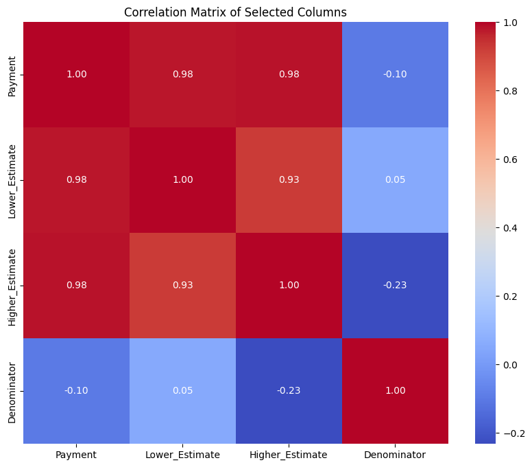

```python
#only for pv_numeric
selected_columns = ['Payment', 'Lower_Estimate', 'Higher_Estimate', 'Denominator']
correlation_matrix = merged_df[selected_columns].corr()
print(correlation_matrix)

#visualization for the matrix
plt.figure(figsize=(10, 8))
sns.heatmap(correlation_matrix, annot=True, cmap='coolwarm', fmt=".2f")
plt.title('Correlation Matrix of Selected Columns')
plt.show()
```

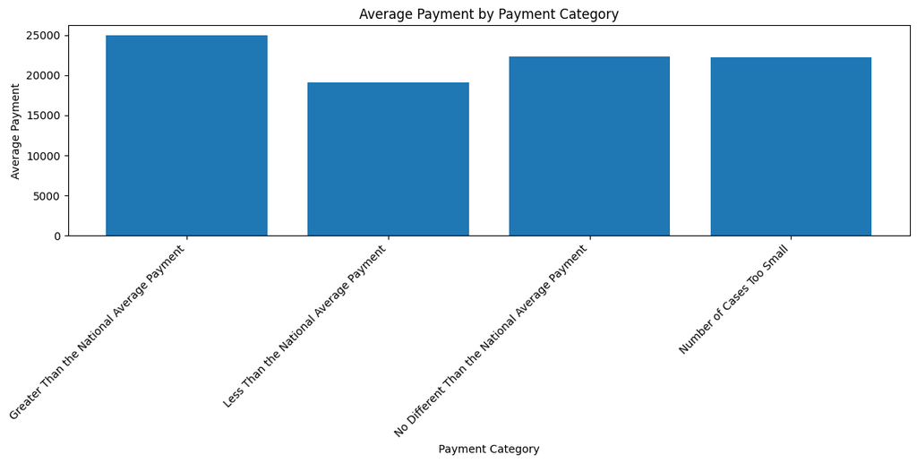

```python
# prompt: create a bar chart of different payments

# Assuming 'merged_df' is your DataFrame with the payment data
# Group the data by Payment_Category and calculate the mean Payment
payment_by_category = merged_df.groupby('Payment_Category')['Payment'].mean()

# Create a bar chart
plt.figure(figsize=(12, 6))
plt.bar(payment_by_category.index, payment_by_category.values)
plt.xlabel('Payment Category')
plt.ylabel('Average Payment')
plt.title('Average Payment by Payment Category')
plt.xticks(rotation=45, ha='right')  # Rotate x-axis labels for better readability
plt.tight_layout()  # Adjust layout to prevent labels from overlapping
plt.show()
```

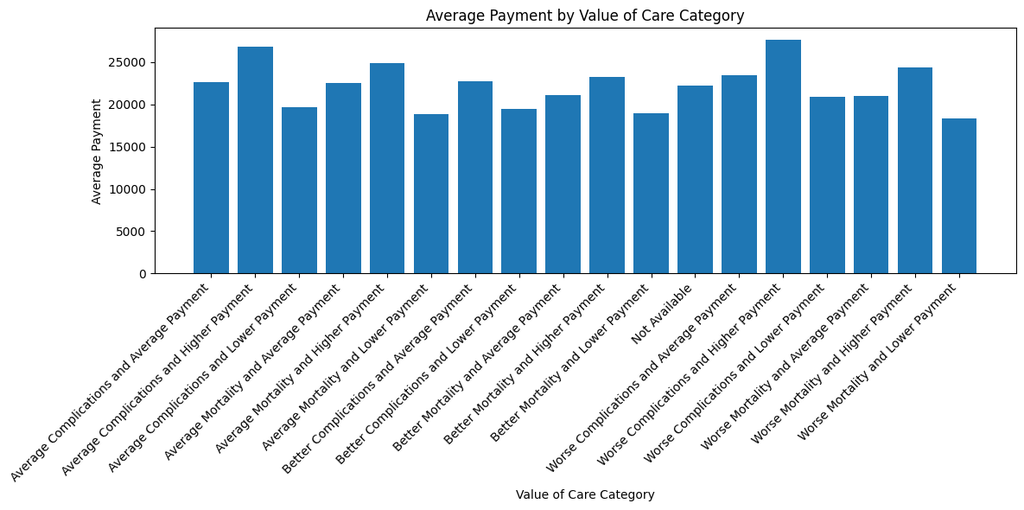

```python
# prompt: create a bar chart of based on value-of-care-category

# Assuming 'merged_df' is your DataFrame with the payment data
# Group the data by Value_of_Care_Category and calculate the mean Payment
payment_by_category = merged_df.groupby('Value_of_Care_Category')['Payment'].mean()

# Create a bar chart
plt.figure(figsize=(12, 6))
plt.bar(payment_by_category.index, payment_by_category.values)
plt.xlabel('Value of Care Category')
plt.ylabel('Average Payment')
plt.title('Average Payment by Value of Care Category')
plt.xticks(rotation=45, ha='right')  # Rotate x-axis labels for better readability
plt.tight_layout()  # Adjust layout to prevent labels from overlapping
plt.show()
```

```python
pv_care_hos['Value_of_Care_Category'].value_counts()
```

| Value_of_Care_Category | count |
| --- | --- |
| Not Available | 8510 |
| Average Mortality and Average Payment | 5768 |
| Average Complications and Average Payment | 980 |
| Average Mortality and Lower Payment | 878 |
| Average Mortality and Higher Payment | 861 |
| Average Complications and Lower Payment | 438 |
| Better Mortality and Average Payment | 279 |
| Worse Mortality and Average Payment | 214 |
| Average Complications and Higher Payment | 191 |
| Better Mortality and Higher Payment | 142 |
| Better Mortality and Lower Payment | 90 |
| Worse Mortality and Lower Payment | 58 |
| Worse Mortality and Higher Payment | 56 |
| Better Complications and Lower Payment | 25 |
| Worse Complications and Higher Payment | 4 |
| Worse Complications and Average Payment | 3 |
| Better Complications and Average Payment | 2 |
| Worse Complications and Lower Payment | 1 |

**dtype:** int64

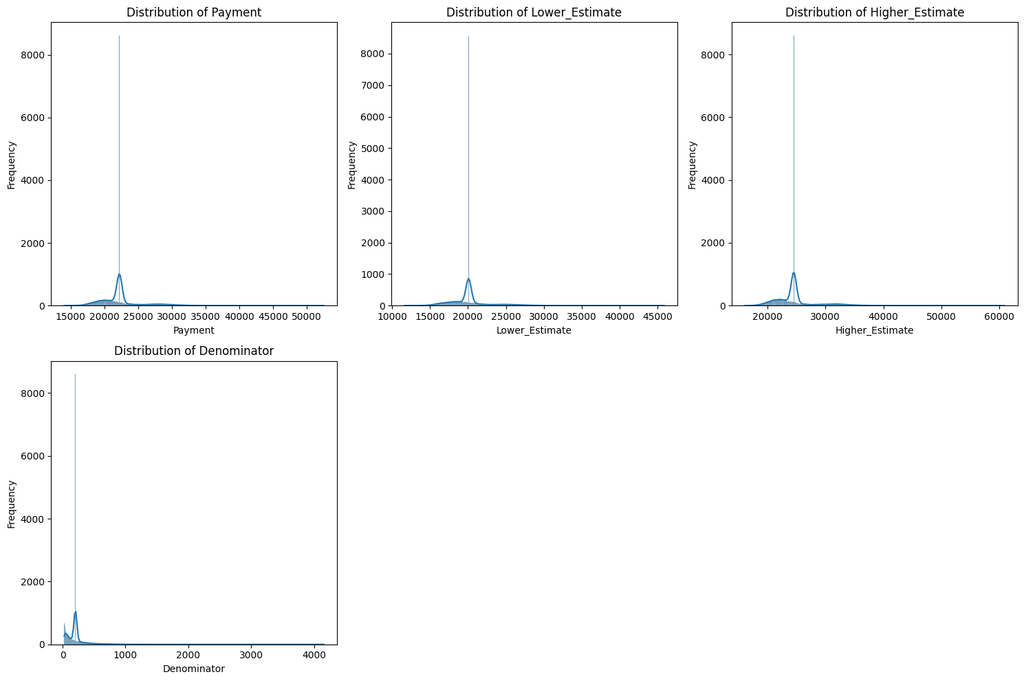

```python
# prompt: Distribution of numeric variables subplots

# Assuming 'df' is your DataFrame with numeric columns
# Create subplots for the distribution of each numeric variable
num_cols = len(df.columns)
num_rows = (num_cols + 2) // 3  # Calculate the number of rows needed

plt.figure(figsize=(15, 5 * num_rows))

for i, col in enumerate(df.columns):
    plt.subplot(num_rows, 3, i + 1)
    sns.histplot(pv_numeric[col], kde=True)  # Use histplot for better visualization
    plt.title(f'Distribution of {col}')
    plt.xlabel(col)
    plt.ylabel('Frequency')

plt.tight_layout()
plt.show()
```

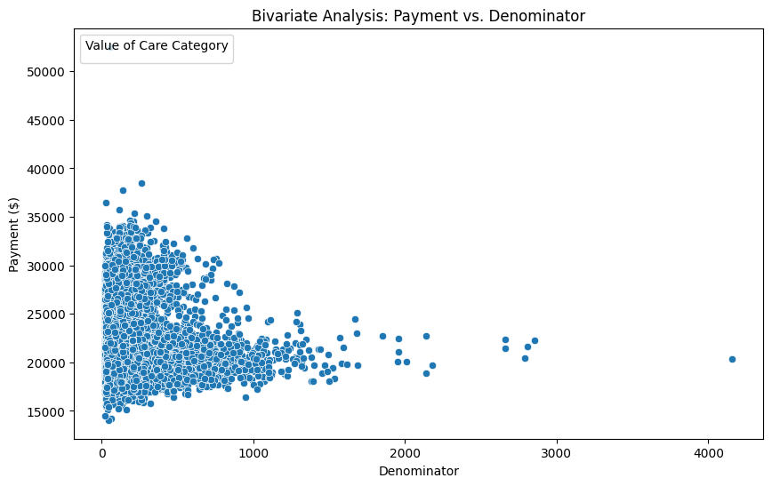

```python
# Bivariate Analysis: Payment vs. Denominator (scatter plot)
plt.figure(figsize=(10, 6))
sns.scatterplot(x=pv_numeric['Denominator'], y=pv_numeric['Payment'], palette='Set1')
plt.title('Bivariate Analysis: Payment vs. Denominator')
plt.xlabel('Denominator')
plt.ylabel('Payment ($)')
plt.legend(title='Value of Care Category', loc='upper left')
plt.show()
```

```python
pv_care_hos.columns
```

[output not shown]

```python
# prompt: print unique values of payment category

print("Unique values of Payment_Category:", pv_care_hos['Payment Category'].unique())
```

[output not shown]

```python
from scipy.stats import iqr

columns = pv_numeric.columns
IQR = {}
lower_threshold = {}
upper_threshold = {}

for col in columns:
    IQR[col] = iqr(pv_numeric[col])


    lower_threshold[col] = np.quantile(pv_numeric[col], 0.25) - 1.5 * IQR[col]
    upper_threshold[col] = np.quantile(pv_numeric[col], 0.75) + 1.5 * IQR[col]

print(f'IQR: {IQR}\n')
print(f'Lower thresholds: {lower_threshold}\n')
print(f'Upper thresholds: {upper_threshold}')
```

```
IQR: {'Payment': 1378.0, 'Lower_Estimate': 1042.0, 'Higher_Estimate': 1708.25, 'Denominator': 90.0}

Lower thresholds: {'Payment': 18794.0, 'Lower_Estimate': 17496.0, 'Higher_Estimate': 20274.375, 'Denominator': -21.0}

Upper thresholds: {'Payment': 24306.0, 'Lower_Estimate': 21664.0, 'Higher_Estimate': 27107.375, 'Denominator': 339.0}
```

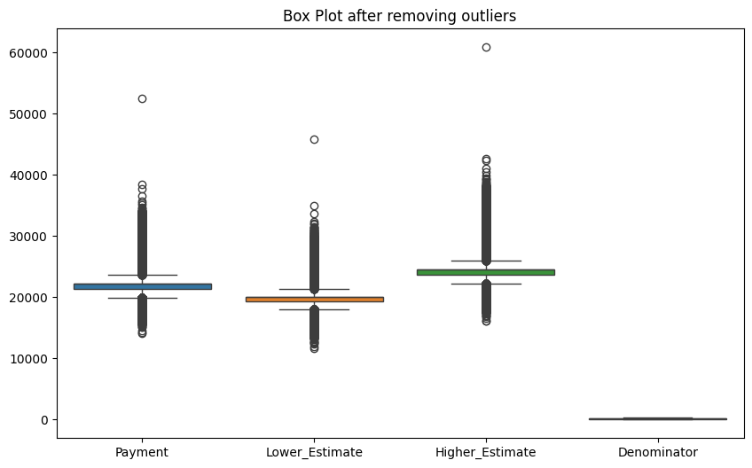

```python
# prompt: create box plot after removing ouliers

import matplotlib.pyplot as plt
import seaborn as sns

# Assuming 'df' is your DataFrame after removing outliers
# (as calculated in the provided code)

plt.figure(figsize=(10, 6))
sns.boxplot(data=df)  # You can specify columns if needed: sns.boxplot(data=df[['Payment', 'Lower_Estimate', 'Higher_Estimate']])
plt.title('Box Plot after removing outliers')
plt.show()
```

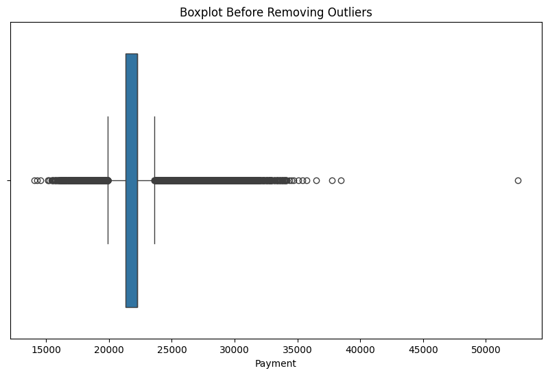

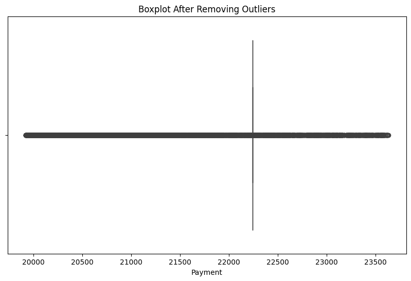

```python
import seaborn as sns
import matplotlib.pyplot as plt

# Step 1: Remove outliers using the IQR method
Q1 = df['Payment'].quantile(0.25)
Q3 = df['Payment'].quantile(0.75)
IQR = Q3 - Q1
lower_bound = Q1 - 1.5 * IQR
upper_bound = Q3 + 1.5 * IQR

# Filter the dataframe to remove the outliers
df_no_outliers_iqr = df[(df['Payment'] >= lower_bound) & (df['Payment'] <= upper_bound)]

# Step 2: Visualize boxplot before and after outlier removal

# Boxplot before removing outliers
plt.figure(figsize=(10, 6))
sns.boxplot(x=df['Payment'])
plt.title('Boxplot Before Removing Outliers')
plt.show()

# Boxplot after removing outliers (using IQR method)
plt.figure(figsize=(10, 6))
sns.boxplot(x=df_no_outliers_iqr['Payment'])
plt.title('Boxplot After Removing Outliers')
plt.show()
```

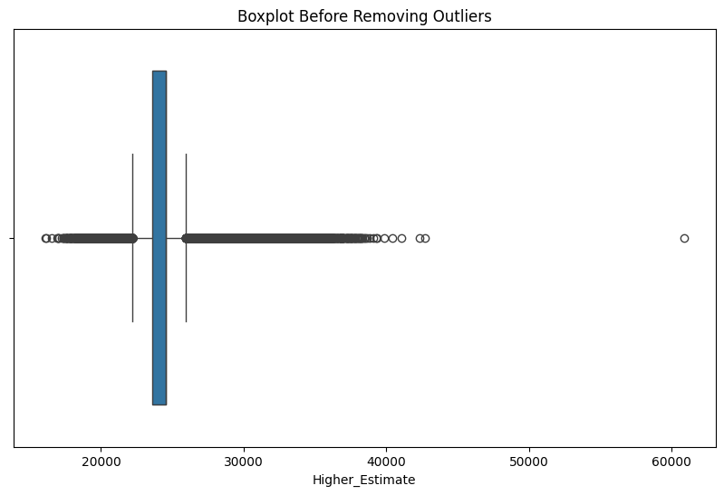

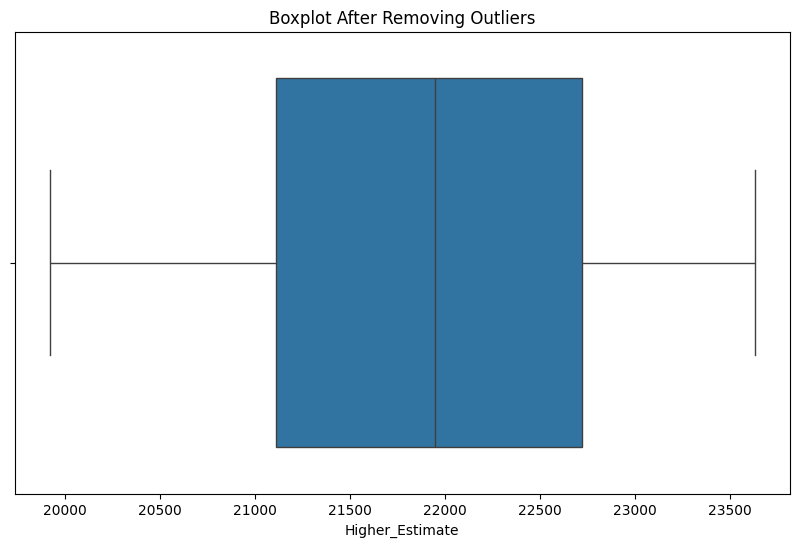

```python
import seaborn as sns
import matplotlib.pyplot as plt

# Step 1: Remove outliers using the IQR method
Q1 = df['Payment'].quantile(0.25)
Q3 = df['Payment'].quantile(0.75)
IQR = Q3 - Q1
lower_bound = Q1 - 1.5 * IQR
upper_bound = Q3 + 1.5 * IQR

# Filter the dataframe to remove the outliers
df_no_outliers_iqr = df[(df['Higher_Estimate'] >= lower_bound) & (df['Higher_Estimate'] <= upper_bound)]

# Step 2: Visualize boxplot before and after outlier removal

# Boxplot before removing outliers
plt.figure(figsize=(10, 6))
sns.boxplot(x=df['Higher_Estimate'])
plt.title('Boxplot Before Removing Outliers')
plt.show()

# Boxplot after removing outliers (using IQR method)
plt.figure(figsize=(10, 6))
sns.boxplot(x=df_no_outliers_iqr['Higher_Estimate'])
plt.title('Boxplot After Removing Outliers')
plt.show()
```

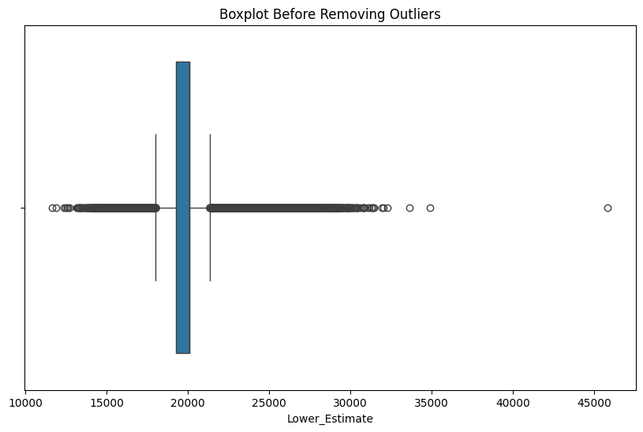

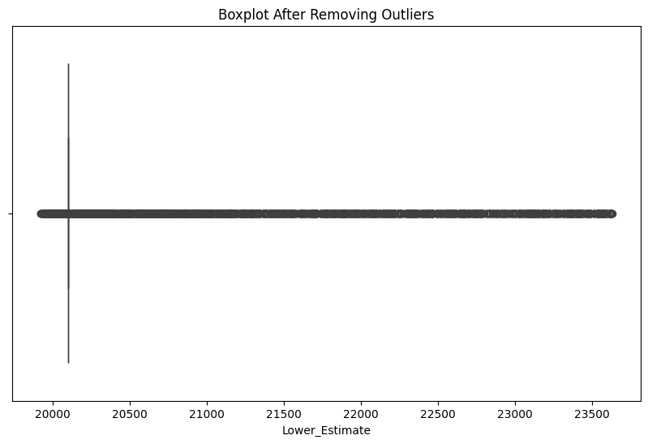

```python
import seaborn as sns
import matplotlib.pyplot as plt

# Step 1: Remove outliers using the IQR method
Q1 = df['Payment'].quantile(0.25)
Q3 = df['Payment'].quantile(0.75)
IQR = Q3 - Q1
lower_bound = Q1 - 1.5 * IQR
upper_bound = Q3 + 1.5 * IQR

# Filter the dataframe to remove the outliers
df_no_outliers_iqr = df[(df['Lower_Estimate'] >= lower_bound) & (df['Lower_Estimate'] <= upper_bound)]

# Step 2: Visualize boxplot before and after outlier removal

# Boxplot before removing outliers
plt.figure(figsize=(10, 6))
sns.boxplot(x=df['Lower_Estimate'])
plt.title('Boxplot Before Removing Outliers')
plt.show()

# Boxplot after removing outliers (using IQR method)
plt.figure(figsize=(10, 6))
sns.boxplot(x=df_no_outliers_iqr['Lower_Estimate'])
plt.title('Boxplot After Removing Outliers')
plt.show()
```

```
Lower Bound: -61.0
Upper Bound: 363.0
Original DataFrame Size: (16693, 4)
Filtered DataFrame Size: (16693, 4)
```

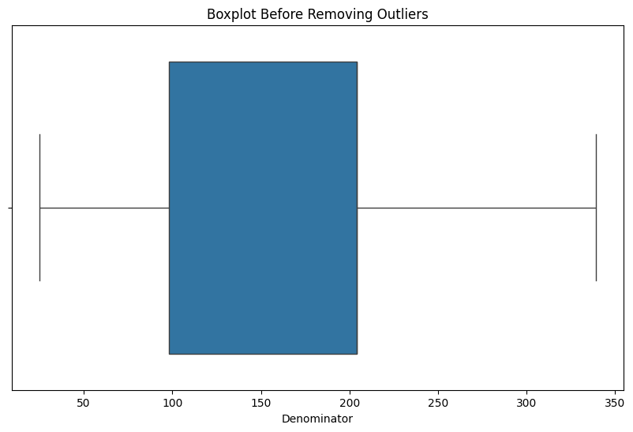

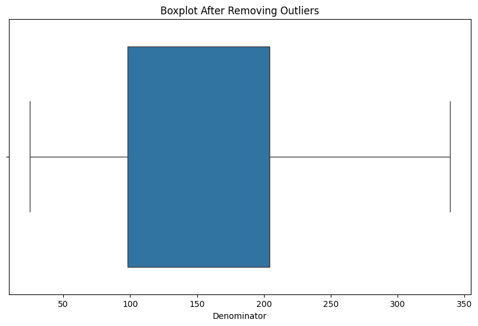

```python
import seaborn as sns
import matplotlib.pyplot as plt

# Step 1: Remove outliers using the IQR method
Q1 = df['Denominator'].quantile(0.25)
Q3 = df['Denominator'].quantile(0.75)
IQR = Q3 - Q1
lower_bound = Q1 - 1.5 * IQR
upper_bound = Q3 + 1.5 * IQR

# Print the bounds to debug
print("Lower Bound:", lower_bound)
print("Upper Bound:", upper_bound)

# Filter the dataframe to remove the outliers
df_no_outliers_iqr = df[(df['Denominator'] >= lower_bound) & (df['Denominator'] <= upper_bound)]

# Check the size of the dataframe before and after removing outliers
print(f"Original DataFrame Size: {df.shape}")
print(f"Filtered DataFrame Size: {df_no_outliers_iqr.shape}")

# Step 2: Visualize boxplot before and after outlier removal

# Boxplot before removing outliers
plt.figure(figsize=(10, 6))
sns.boxplot(x=df['Denominator'])
plt.title('Boxplot Before Removing Outliers')
plt.show()

# Boxplot after removing outliers (using IQR method)
if df_no_outliers_iqr.shape[0] > 0:  # Check if there are data points left
    plt.figure(figsize=(10, 6))
    sns.boxplot(x=df_no_outliers_iqr['Denominator'])
    plt.title('Boxplot After Removing Outliers')
    plt.show()
else:
    print("No data left after removing outliers.")
```

```python
pv_care_hos.columns
```

[output not shown]

### **KPI**

```python
payment_categories = ['Payment for heart attack patients',
       'Payment for heart failure patients',
       'Payment for pneumonia patients',
       'Payment for hip/knee replacement patients']

# Create a dictionary to map Payment_Measure_Name to payment categories
category_mapping = {
    'Payment for heart attack patients': 'Heart Attack',
    'Payment for heart failure patients': 'Heart Failure',
    'Payment for pneumonia patients': 'Pneumonia',
    'Payment for hip/knee replacement patients': 'Hip/Knee Replacement'
    # Add more mappings as needed
}


# Add a new column 'Payment_Category' based on 'Payment_Measure_Name'
merged_df['New_Payment_Category'] = merged_df['Payment_Measure_Name'].map(category_mapping)

#Handle missing values in 'New_Payment_Category' if any
merged_df['New_Payment_Category'].fillna('Unknown', inplace=True)


# Now you can group data by 'New_Payment_Category' and analyze payments
payment_by_category = merged_df.groupby('New_Payment_Category')['Payment'].mean()
payment_by_category
```

| New_Payment_Category | Payment |
| --- | --- |
| Heart Attack | 24831.745297 |
| Heart Failure | 20527.695784 |
| Hip/Knee Replacement | 22254.690378 |
| Pneumonia | 21341.700324 |

**dtype:** Float64

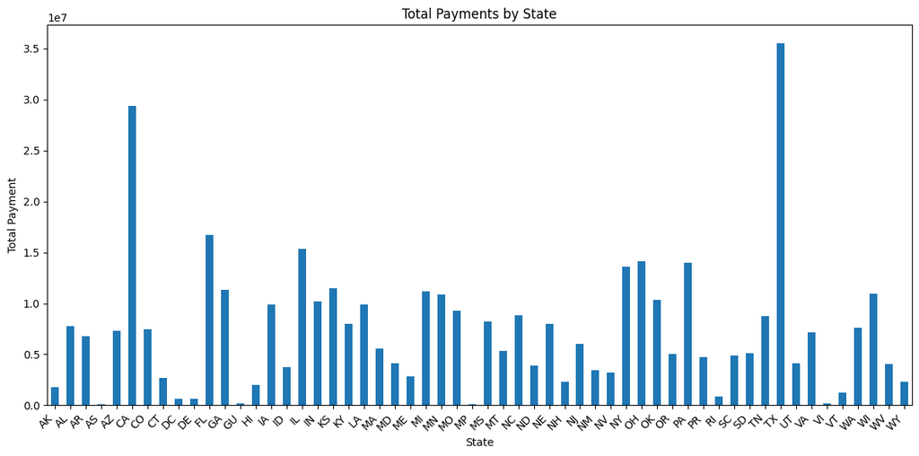

```python
# Group payments by state and sum them
state_payments = merged_df.groupby('State')['Payment'].sum()

# Create a bar chart
plt.figure(figsize=(12, 6))
state_payments.plot(kind='bar')
plt.xlabel('State')
plt.ylabel('Total Payment')
plt.title('Total Payments by State')
plt.xticks(rotation=45, ha='right')
plt.tight_layout()
plt.show()
```

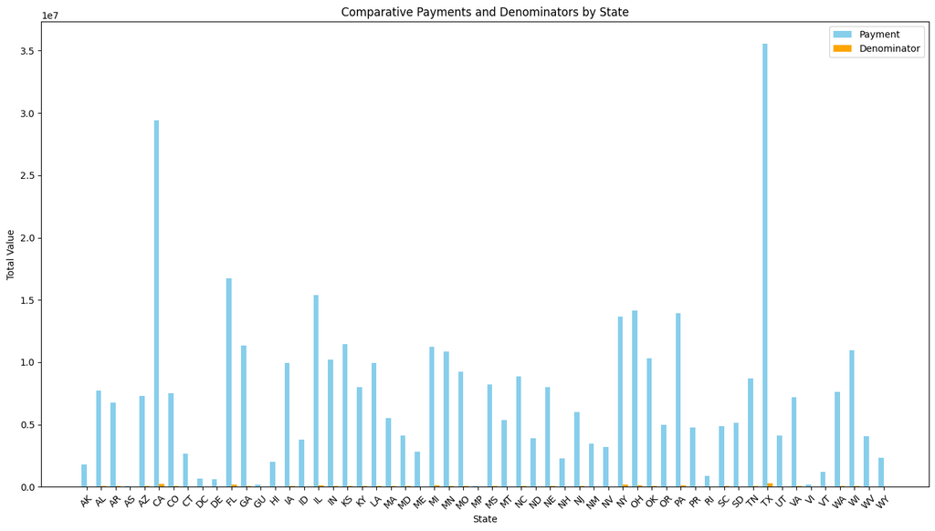

```python
import matplotlib.pyplot as plt
import seaborn as sns

# Assuming 'merged_df' is your DataFrame and has 'State', 'Payment', and 'Denominator' columns

# Group by 'State' and calculate the sum of 'Payment' and 'Denominator' for each state
state_comparison = merged_df.groupby('State')[['Payment', 'Denominator']].sum().reset_index()

# Create a figure and axis
plt.figure(figsize=(14, 8))

# Set the positions of the bars on the x-axis
bar_width = 0.35
index = range(len(state_comparison))

# Plot the bars for 'Payment' and 'Denominator' side by side
plt.bar(index, state_comparison['Payment'], bar_width, label='Payment', color='skyblue')
plt.bar([i + bar_width for i in index], state_comparison['Denominator'], bar_width, label='Denominator', color='orange')

# Set labels, title, and legend
plt.xlabel('State')
plt.ylabel('Total Value')
plt.title('Comparative Payments and Denominators by State')
plt.xticks([i + bar_width / 2 for i in index], state_comparison['State'], rotation=45)

# Add a legend
plt.legend()

# Adjust the layout for better spacing
plt.tight_layout()

# Display the plot
plt.show()
```

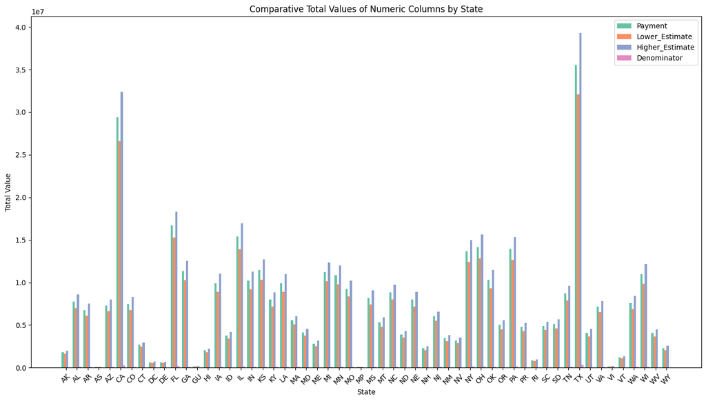

```python
import matplotlib.pyplot as plt
import seaborn as sns

# Assuming 'merged_df' is your DataFrame
# Select only numeric columns from the DataFrame
numeric_columns = ['Payment', 'Lower_Estimate', 'Higher_Estimate', 'Denominator']

# Group by 'State' and sum up the values of the numeric columns
state_comparison = merged_df.groupby('State')[numeric_columns].sum().reset_index()

# Create a figure and axis
plt.figure(figsize=(14, 8))

# Set the positions of the bars on the x-axis
bar_width = 0.2
index = range(len(state_comparison))

# Plot each numeric column as a bar
colors = sns.color_palette("Set2", len(numeric_columns))  # Using Seaborn color palette for different colors
for i, column in enumerate(numeric_columns):
    plt.bar(
        [x + i * bar_width for x in index],  # Shift bars for each column
        state_comparison[column],
        bar_width,
        label=column,
        color=colors[i]
    )

# Set labels, title, and legend
plt.xlabel('State')
plt.ylabel('Total Value')
plt.title('Comparative Total Values of Numeric Columns by State')
plt.xticks([x + bar_width * (len(numeric_columns) / 2 - 0.5) for x in index], state_comparison['State'], rotation=45)

# Add a legend to distinguish the columns
plt.legend()

# Adjust the layout for better spacing
plt.tight_layout()

# Display the plot
plt.show()
```

- Final EDA insights
  - payment(higher estimate,lower estimate) says which states have higher payment suggest most in demand hospitals for the people , we can say **value of care Hospitals** in those states (TX,CA,FL,IL,OH)

```python
import pandas as pd

# Assuming merged_df is your DataFrame
payment_by_measure = merged_df.groupby('Payment_Measure_ID')['Lower_Estimate'].mean().reset_index()
higher_payment_by_measure = merged_df.groupby('Payment_Measure_ID')['Higher_Estimate'].mean().reset_index()
lower_payment_by_measure = merged_df.groupby('Payment_Measure_ID')['Denominator'].mean().reset_index()
```

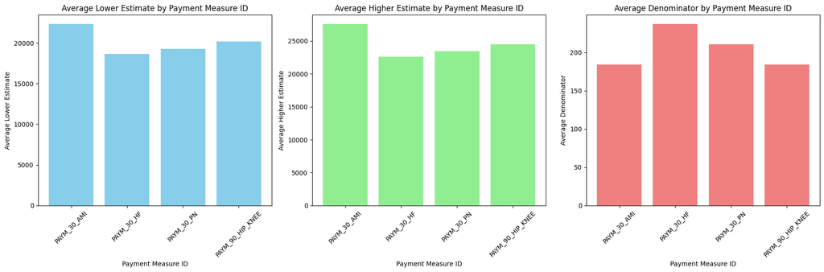

```python
import pandas as pd
import matplotlib.pyplot as plt

# Assuming merged_df is your DataFrame
payment_by_measure = merged_df.groupby('Payment_Measure_ID')['Lower_Estimate'].mean().reset_index()
higher_payment_by_measure = merged_df.groupby('Payment_Measure_ID')['Higher_Estimate'].mean().reset_index()
lower_payment_by_measure = merged_df.groupby('Payment_Measure_ID')['Denominator'].mean().reset_index()

# Create the figure and axes for subplots
fig, axs = plt.subplots(1, 3, figsize=(18, 6))  # 1 row, 3 columns of subplots

# Plot the first chart for Lower Estimate
axs[0].bar(payment_by_measure['Payment_Measure_ID'], payment_by_measure['Lower_Estimate'], color='skyblue')
axs[0].set_xlabel('Payment Measure ID')
axs[0].set_ylabel('Average Lower Estimate')
axs[0].set_title('Average Lower Estimate by Payment Measure ID')
axs[0].tick_params(axis='x', rotation=45)

# Plot the second chart for Higher Estimate
axs[1].bar(higher_payment_by_measure['Payment_Measure_ID'], higher_payment_by_measure['Higher_Estimate'], color='lightgreen')
axs[1].set_xlabel('Payment Measure ID')
axs[1].set_ylabel('Average Higher Estimate')
axs[1].set_title('Average Higher Estimate by Payment Measure ID')
axs[1].tick_params(axis='x', rotation=45)

# Plot the third chart for Denominator
axs[2].bar(lower_payment_by_measure['Payment_Measure_ID'], lower_payment_by_measure['Denominator'], color='lightcoral')
axs[2].set_xlabel('Payment Measure ID')
axs[2].set_ylabel('Average Denominator')
axs[2].set_title('Average Denominator by Payment Measure ID')
axs[2].tick_params(axis='x', rotation=45)

# Adjust the layout for better display
plt.tight_layout()

# Show the chart
plt.show()
```

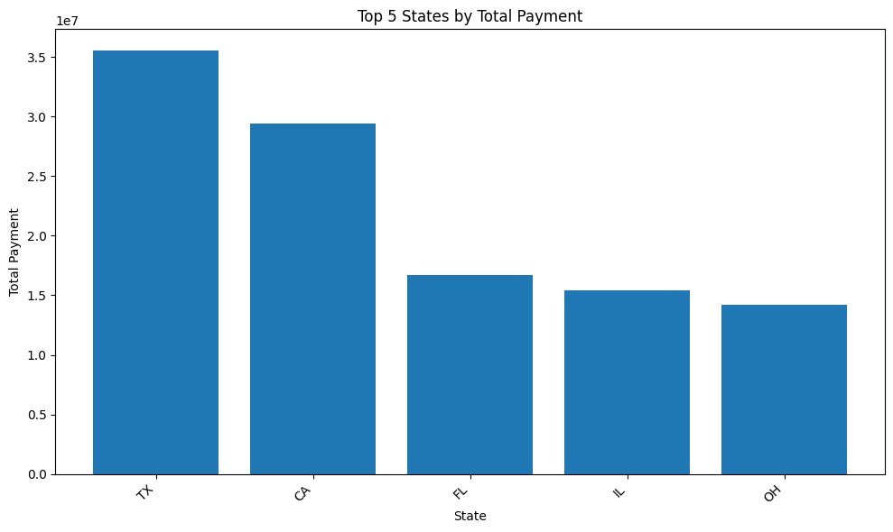

```python
# prompt: create a chart for top 5 states

import matplotlib.pyplot as plt

# Assuming 'merged_df' is your DataFrame and 'State' and 'Payment' columns exist
top_5_states = merged_df.groupby('State')['Payment'].sum().nlargest(5)

plt.figure(figsize=(10, 6))
plt.bar(top_5_states.index, top_5_states.values)
plt.xlabel('State')
plt.ylabel('Total Payment')
plt.title('Top 5 States by Total Payment')
plt.xticks(rotation=45, ha='right')
plt.tight_layout()
plt.show()
```